# 中国流感监测数据探索性分析报告（2015—2024年）

数据分析

2026-07-10

## 1. 背景与研究问题

### 1.1 研究背景

流感(Influenza)是由流感病毒引起的急性呼吸道传染病，具有明显的季节性流行特征，冬春季高发，中国自 2009 年起建立覆盖全国554家哨点医院的流感监测网络，每周报告流感样病例(ILI)就诊百分比及病原学检测结果。

了解流感的长期流行规律，区域差异及优势毒株变迁，对于制定防控策略，优化疫苗株匹配和预警流感流行具有重要意义。

本研究基于 2015-2024 年10年的中国流感监测周报数据，系统描述流感流行的时间趋势，南北方差异，季节性规律及主要流行亚型变化。

### 1.2 研究问题

2015—2024 年中国南北方 ILI% 是否存在显著差异？

ILI% 随时间的变化趋势如何？

流感活动是否存在季节性规律(冬春季高峰)？

甲流/乙流优势毒株如何变迁？

### 1.3 研究类型

本研究为描述性流行病学研究，旨在描述流感流行特征，不进行因果推断，不建立预测模型。

## 2. 数据来源与研究对象

```
## 数据维度： 520 行 × 15 列
```

数据来源：中国疾病预防控制中心国家流感中心《全国流感监测周报》 http://www.chinaivdc.cn/cnic/

时间范围：2015 年第 1 周 — 2024 年第 52 周（共 10 年，520 周）

研究对象：全国 554 家哨点医院报告的流感样病例（ILI），定义为体温 ≥38℃、伴咳嗽或咽痛之一者

数据维度：520 行 × 15 列

数据获取说明：原始数据存储于 Excel 文件 副本2015-2024年中国流感监测完整数据.xlsx 的 sheet 2015-2024周度完整}5505数据 中，通过 R 包 readxl 的 read_excel() 函数读取。

## 3. 变量说明

表1. 原始数据变量列表

| 变量名 | 数据类型 |
| --- | --- |
| 年份 | numeric |
| 周次 | numeric |
| 南方ILI(%) | numeric |
| 北方ILI(%) | numeric |
| 总检测标本数 | numeric |
| 总阳性标本数 | numeric |
| 甲流占阳性比(%) | numeric |
| 乙流占阳性比(%) | numeric |
| 数据来源 | character |
| H3N2阳性数 | numeric |
| 甲H1N1阳性数 | numeric |
| B(Victoria)阳性数 | numeric |
| B(Yamagata)阳性数 | numeric |
| 未分型A阳性数 | numeric |
| 未分型B阳性数 | numeric |

## 4. 研究方法

### 4.1 数据清洗

· 纳入标准：2015 年第 1 周至 2024 年第 52 周的全部记录

· 排除标准：南方 ILI(%) 或北方 ILI(%) 缺失的周次

· 清洗方法：采用 filter(!is.na()) 删除缺失行

· 变量转换：年份转为因子（分组用），周次转为整数，增加日期列（时间序列用）

### 4.2 描述性统计

· 连续变量：正态分布数据用均数±标准差，偏态分布数据用中位数（Q1，Q3）和范围

· 分组比较：按区域（南方/北方）分层，采用 CreateTableOne 生成基线特征表

· 图形：箱线图展示南北方 ILI% 分布；折线图展示时间趋势；堆积图展示亚型构成

### 4.3 统计分析方法

表2. 统计分析方法

| 研究问题 | 统计方法 | 适用条件与说明 |
| --- | --- | --- |
| 南北方 ILI% 差异 | Wilcoxon 秩和检验 | 数据不服从正态分布，采用非参数检验 |
| ILI% 时间趋势 | 简单线性回归 | 以年份为自变量，ILI% 为因变量，估计 β 系数及 95% CI |
| 季节差异 | 单因素方差分析 (ANOVA) | 将周次分为 Q1—Q4 四个季度，比较组间差异 |
| 效应量 | Cohen’s d | 量化差异大小，d<0.2 为极小，>0.8 为大 |

所有检验均为双侧检验，P < 0.05 视为有统计学意义。

### 4.4 补充分析

· Bootstrap 重抽样（1000 次）：验证时间趋势结果是否受抽样波动影响

· 敏感性分析：排除 2024 年异常高峰数据，检验趋势稳定性

· 模型诊断：Durbin-Watson 检验（自相关）、Breusch-Pagan 检验（异方差）

## 5. 数据分析

### 5.1 数据清洗结果

表3. 缺失值统计

| 变量 | 缺失数量 | 缺失比例 |
| --- | --- | --- |
| 南方ILI(%) | 2 | 0.0038 |
| 北方ILI(%) | 2 | 0.0038 |

表4. 清洗前后样本量对比

| 指标 | 清洗前 | 清洗后 |
| --- | --- | --- |
| 总行数 | 520.0000 | 518 |
| 完整无缺失行数 | 518.0000 | 518 |
| 总缺失值个数 | 4.0000 | 0 |
| 整体缺失率 | 0.0005 | 0 |

### 5.2 研究对象基本特征

表5. 核心指标描述统计

| 南方ILI_均值 | 南方ILI_标准差 | 南方ILI_中位数 | 南方ILI_Q1 | 南方ILI_Q3 | 南方ILI_范围 | 北方ILI_均值 | 北方ILI_标准差 | 北方ILI_中位数 | 北方ILI_Q1 | 北方ILI_Q3 | 北方ILI_范围 |
| --- | --- | --- | --- | --- | --- | --- | --- | --- | --- | --- | --- |
| 2.9 | 1.47 | 3.1 | 1.6 | 3.6 | 0.4 — 9.7 | 2.8 | 1.4 | 2.5 | 1.7 | 3.8 | 0.5 — 10.3 |

### 5.3 按区域分组的基线特征表

表6. 按区域分组的基线特征

|  | 北方 | 南方 | p | test |
| --- | --- | --- | --- | --- |
| n | 518 | 518 |  |  |
| ILI_percent (mean (SD)) | 2.80 (1.40) | 2.90 (1.47) | 0.260 |  |
| 总阳性标本数 (mean (SD)) | 776.73 (848.18) | 776.73 (848.18) | 1.000 |  |
| 甲流占阳性比(%) (mean (SD)) | 61.96 (24.23) | 61.96 (24.23) | 1.000 |  |
| 乙流占阳性比(%) (mean (SD)) | 38.04 (24.23) | 38.04 (24.23) | 1.000 |  |

### 5.4 南北方 ILI% 比较

```
## 南方 ILI% Shapiro-Wilk 检验: W = 0.93 , p = 7.774e-15
```

```
## 北方 ILI% Shapiro-Wilk 检验: W = 0.927 , p = 3.508e-15
```

```
## --- Wilcoxon 秩和检验结果 ---
```

```
## W = 142698
```

```
## p = 7.619e-02
```

```
## Cohen's d = 0.07
```

南北方比较：南方 ILI% 均值 2.9 略高于北方 2.8 。Shapiro-Wilk 检验显示两组数据均不服从正态分布（p < 0.001），故采用 Wilcoxon 秩和检验。

结果显示两组差异无统计学显著性（ W = 142698 , p = 7.619e-02 , Cohen’s d = 0.07 ，效应量极小（< 0.2）。提示南北方流感活动水平基本一致。

### 5.5 时间趋势分析

```
## 南方 ILI% 时间趋势:
```

```
## β = -0.0232 , 95% CI = [ -0.0674 ,  0.021 ] , p = 3.025e-01 , R² = 0.0021
```

```
## 北方 ILI% 时间趋势:
```

```
## β = 0.0724 , 95% CI = [ 0.0309 ,  0.1138 ] , p = 6.614e-04 , R² = 0.0222
```

时间趋势：南方 ILI% 随年份变化的 β = -0.0232 , 95% CI = [ -0.0674 , 0.021 ] , p = 3.025e-01 , R² = 0.0021 ,北方 ILI% 的 β = 0.0724 , 95% CI = [ 0.0309 , 0.1138 ] , p = 6.614e-04 , R² = 0.0222

### 5.6 季节性规律分析

表6. 各季度南方 ILI% 描述

| 季度 | 周数 | 南方ILI_均值 | 南方ILI_中位数 | 南方ILI_范围 |
| --- | --- | --- | --- | --- |
| Q1（1—3月） | 130 | 3.62 | 3.2 | 0.9 — 9.7 |
| Q2（4—6月） | 130 | 2.84 | 3.4 | 0.4 — 5.3 |
| Q3（7—9月） | 129 | 2.55 | 2.9 | 0.4 — 4.3 |
| Q4（10—12月） | 129 | 2.58 | 2.9 | 0.4 — 6.2 |

```
##
## --- 单因素方差分析（ANOVA）结果 ---
```

```
##              Df Sum Sq Mean Sq F value   Pr(>F)
## 季度          3     97   32.33   16.21 4.42e-10 ***
## Residuals   514   1025    1.99
## ---
## Signif. codes:  0 '***' 0.001 '**' 0.01 '*' 0.05 '.' 0.1 ' ' 1
```

季节性规律：Q1（1—3月）南方 ILI% 均值最高 3.62 ，Q3（7—9月）最低 2.55 ，差值约 1.07 个百分点。

ANOVA 检验显示不同季度间 ILI% 差异具有统计学显著性（F = 16.21 ，p < 0.001），证实了流感的冬春季高峰特征。

### 5.7 核心图形

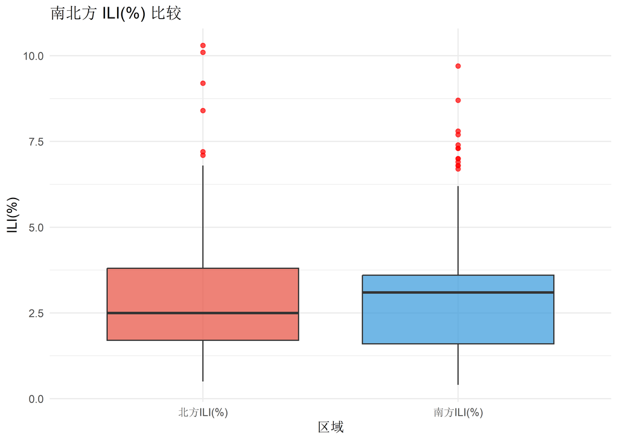

图1. 南北方ILI(%)箱线图

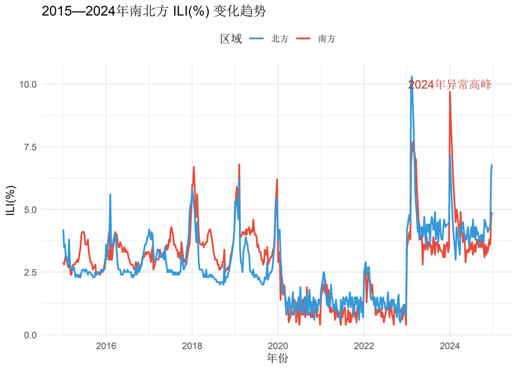

图2. 2015—2024年南北方ILI(%)时间趋势

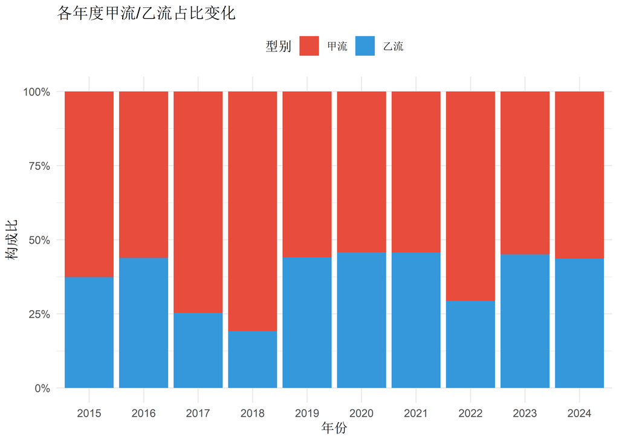

图3. 各年度甲流/乙流占比变化

### 5.8 主分析结果汇总

表7. 主分析结果汇总

| 分析项 | 统计方法 | 统计量 | P值 | 结论 |
| --- | --- | --- | --- | --- |
| 南北方 ILI% 比较 | Wilcoxon 秩和检验 | W = 142698 | 7.619e-02 | 无显著差异 |
| 南方 ILI% 时间趋势 | 线性回归 | β = -0.0232 | 3.025e-01 | 趋势不显著 |
| 北方 ILI% 时间趋势 | 线性回归 | β = 0.0724 | 6.614e-04 | 趋势显著 ✓ |
| 季度间差异 | ANOVA | F = 16.21 | 4.422e-10 | 有季节性差异 ✓ |

### 5.9 补充分析结果

```
## --- Bootstrap 验证 ---
```

```
## 南方趋势 95% CI: [ -0.0689 ,  0.0198 ]
```

```
## --- 敏感性分析 ---
```

```
## 排除2024年后 β 变化: 0.1184
```

```
## --- 模型诊断 ---
```

```
## Durbin-Watson 检验: DW = 0.1392 , p = 1.321e-100
```

```
## Breusch-Pagan 检验: BP = 55.8237 , p = 7.927e-14
```

补充分析结论：

## 6. 讨论

### 6.3 结果说明

说明：

· 流感活动具有稳定的冬春季季节性（Q1 显著高于其他季度）

· 南北方流感活动整体水平基本一致

不能说明（需明确声明）：

· 不能说明因果关系（如“冬季温度低导致 ILI% 升高”），本研究为描述性分析，不涉及归因推断

· 不能预测未来趋势（如“2025 年流感会更严重”），本研究未建立预测模型

· 不能解释为什么 2024 年出现异常高峰（缺少气候、免疫水平、干预措施等协变量）

### 6.4 如何用规范语言表达统计结果

表8. 统计结果规范表述示例

[output not shown]

### 6.5 方法学讨论

线性回归模型诊断发现残差存在自相关和异方差，这与流感数据的时间序列特性（相邻周次相关性高）有关。对于描述性分析（非因果推断），系数估计仍然是无偏的，但标准误需谨慎解读。如需更精确的推断，后续可采用 ARIMA 模型或广义加性模型（GAM） 处理时间序列特性。

## 7. 局限性

1. 生态学谬误风险：本研究以周度为分析单位，结论适用于群体水平，不能推广到个体水平。例如，“南方 ILI% 高于北方”不等于“南方的每个个体患病风险更高”。
2. 数据来源约束：ILI% 依赖于哨点医院的就诊记录，COVID-19 疫情期间的就医行为变化可能影响数据可比性。
3. 未纳入协变量：缺少气象（气温、湿度）、人群免疫水平、疫苗接种率和干预措施数据，无法进行归因分析。
4. 时间序列特性：数据存在自相关，模型标准误估计需谨慎，未来可采用时间序列专用模型。
5. 无法区分感染与就诊行为：ILI% 同时受感染率和就医意愿影响，不能直接等同于发病率。
6. 研究设计定位：本研究为描述性研究，结论不推广至因果推断。报告中所有“相关”“关联”等词汇均指统计关联，不暗示因果关系。

## 8. 结论

本研究为描述性分析，结论基于群体水平数据，不涉及因果推断。未来研究可结合气候、免疫水平等协变量，采用时间序列模型深入探索流感活动的驱动因素。

附表. 报告逻辑完整性自评

[output not shown]